## Agenda

- what are pipes?
- why use pipes?
- what are the different types of pipes?
- combining operations with pipes
- case studies

## Introduction

R code contain a lot of parentheses in case of a sequence of multiple operations. When you are dealing with complex code, it results in nested function calls which are hard to read and maintain. The magrittr package by [Stefan Milton Bache](http://stefanbache.dk/) provides pipes enabling us to write R code that is readable.

Pipes allow us to clearly express a sequence of multiple operations by:

- structuring operations from left to right
- avoiding
  - nested function calls
  - intermediate steps
  - overwriting of original data
- minimizing creation of local variables

## Pipes

If you are using [tidyverse](https://www.tidyverse.org/), magrittr will be automatically loaded. We will look at 3 different types of pipes:

- `%>%` : pipe a value forward into an expression or function call
- `%<>%`: result assigned to left hand side object instead of returning it
- `%$%` : expose names within left hand side objects to right hand side expressions

## Libraries

```r
library(magrittr)
library(readr)
library(purrr)
library(dplyr)
library(stringr)
```

## Data

```
## # A tibble: 1,000 x 4
##    referrer n_pages duration purchase
##    <fct>      <dbl>    <dbl> <lgl>
##  1 google         1      693 FALSE
##  2 yahoo          1      459 FALSE
##  3 direct         1      996 FALSE
##  4 bing          18      468 TRUE
##  5 yahoo          1      955 FALSE
##  6 yahoo          5      135 FALSE
##  7 yahoo          1       75 FALSE
##  8 direct         1      908 FALSE
##  9 bing          19      209 FALSE
## 10 google         1      208 FALSE
## # ... with 990 more rows
```

## Data Dictionary

- referrer: referrer website/search engine
- n_pages: number of pages visited
- duration: time spent on the website (in seconds)
- purchase: whether visitor purchased

## Sample Data

```r
ecom_mini <- sample_n(ecom, size = 10)
```

## head

```r
head(ecom, 10)
```

```
## # A tibble: 10 x 4
##    referrer n_pages duration purchase
##    <fct>      <dbl>    <dbl> <lgl>
##  1 google         1      693 FALSE
##  2 yahoo          1      459 FALSE
##  3 direct         1      996 FALSE
##  4 bing          18      468 TRUE
##  5 yahoo          1      955 FALSE
##  6 yahoo          5      135 FALSE
##  7 yahoo          1       75 FALSE
##  8 direct         1      908 FALSE
##  9 bing          19      209 FALSE
## 10 google         1      208 FALSE
```

## Using pipe

```r
ecom %>% head(10)
```

```
## # A tibble: 10 x 4
##    referrer n_pages duration purchase
##    <fct>      <dbl>    <dbl> <lgl>
##  1 google         1      693 FALSE
##  2 yahoo          1      459 FALSE
##  3 direct         1      996 FALSE
##  4 bing          18      468 TRUE
##  5 yahoo          1      955 FALSE
##  6 yahoo          5      135 FALSE
##  7 yahoo          1       75 FALSE
##  8 direct         1      908 FALSE
##  9 bing          19      209 FALSE
## 10 google         1      208 FALSE
```

## Square Root

```r
y <- ecom_mini$n_pages
y <- sqrt(y)

# combine above steps
sqrt(ecom_mini$n_pages)
```

```
##  [1] 1.000000 1.000000 2.000000 1.000000 4.472136 1.000000 1.414214
##  [8] 1.000000 1.414214 1.000000
```

## Square Root - Using pipe

```r
# select n_pages variable and assign it to y
ecom_mini %$%
  n_pages -> y

# compute square root of y and assign it to y
y %<>% sqrt()
```

## Square Root - Using Pipe

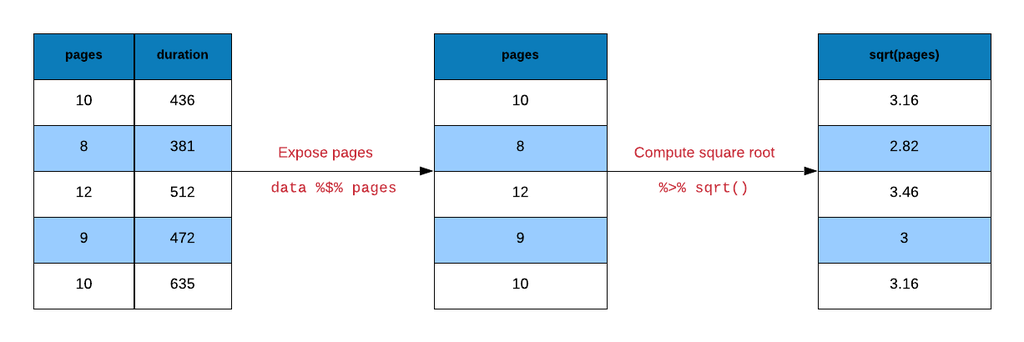

## Square Root - Using pipe

```r
ecom_mini %$%
  n_pages %>%
  sqrt() -> y

y
```

```
##  [1] 1.000000 1.000000 2.000000 1.000000 4.472136 1.000000 1.414214
##  [8] 1.000000 1.414214 1.000000
```

## Correlation

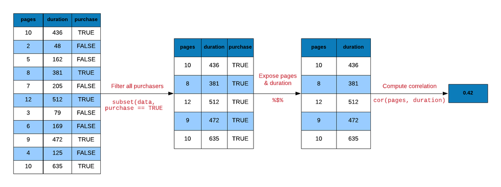

## Correlation

```r
# without pipe
ecom1 <- subset(ecom, purchase)
cor(ecom1$n_pages, ecom1$duration)
```

```
## [1] 0.4290905
```

## Correlation - Using pipe

```r
# with pipe
ecom %>%
  subset(purchase) %$%
  cor(n_pages, duration)
```

```
## [1] 0.4290905
```

```r
# using filter from dplyr and pipe
ecom %>%
  filter(purchase) %$%
  cor(n_pages, duration)
```

```
## [1] 0.4290905
```

## Visualization

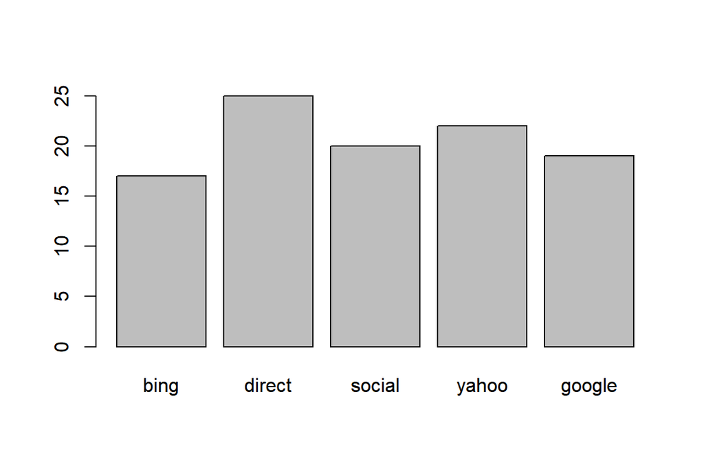

```r
barplot(table(subset(ecom, purchase)$referrer))
```

## Visualization

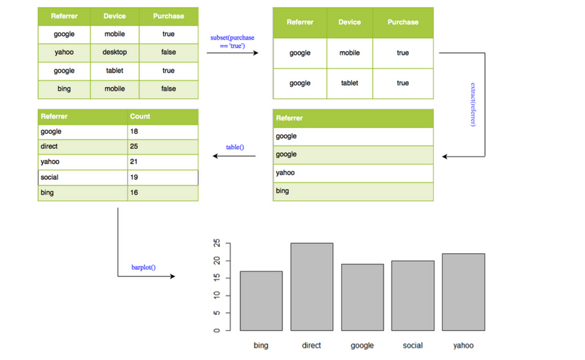

## Visualization - Using pipe

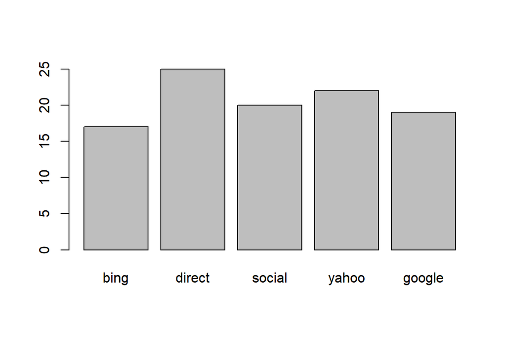

```r
ecom %>%
  subset(purchase) %>%
  extract('referrer') %>%
  table() %>%
  barplot()
```

## Regression

```r
summary(lm(duration ~ n_pages, data = ecom))
```

```
##
## Call:
## lm(formula = duration ~ n_pages, data = ecom)
##
## Residuals:
##     Min      1Q  Median      3Q     Max
## -386.45 -213.03  -38.93  179.31  602.55
##
## Coefficients:
##             Estimate Std. Error t value Pr(>|t|)
## (Intercept)  404.803     11.323  35.750  < 2e-16 ***
## n_pages       -8.355      1.296  -6.449 1.76e-10 ***
## ---
## Signif. codes:  0 '***' 0.001 '**' 0.01 '*' 0.05 '.' 0.1 ' ' 1
##
## Residual standard error: 263.3 on 998 degrees of freedom
## Multiple R-squared:   0.04,  Adjusted R-squared:  0.03904
## F-statistic: 41.58 on 1 and 998 DF,  p-value: 1.756e-10
```

## Regression - Using pipe

```r
ecom %$%
  lm(duration ~ n_pages) %>%
  summary()
```

```
##
## Call:
## lm(formula = duration ~ n_pages)
##
## Residuals:
##     Min      1Q  Median      3Q     Max
## -386.45 -213.03  -38.93  179.31  602.55
##
## Coefficients:
##             Estimate Std. Error t value Pr(>|t|)
## (Intercept)  404.803     11.323  35.750  < 2e-16 ***
## n_pages       -8.355      1.296  -6.449 1.76e-10 ***
## ---
## Signif. codes:  0 '***' 0.001 '**' 0.01 '*' 0.05 '.' 0.1 ' ' 1
##
## Residual standard error: 263.3 on 998 degrees of freedom
## Multiple R-squared:   0.04,  Adjusted R-squared:  0.03904
## F-statistic: 41.58 on 1 and 998 DF,  p-value: 1.756e-10
```

## String Manipulation

```r
email <- 'jovialcann@anymail.com'

# without pipe
str_to_upper(str_sub(str_split(email, '@')[[1]][1], start = 1, end = 6))
```

```
## [1] "JOVIAL"
```

## String Manipulation - Using Pipe

```r
# with pipe
email %>%
  str_split(pattern = '@') %>%
  extract2(1) %>%
  extract(1) %>%
  str_sub(start = 1, end = 6) %>%
  str_to_upper()
```

```
## [1] "JOVIAL"
```

## Data Extraction

- `extract()`
- `extract2()`
- `use_series()`

## Extract Column By Name

```r
ecom_mini['n_pages']
```

```
## # A tibble: 10 x 1
##    n_pages
##      <dbl>
##  1       1
##  2       1
##  3       4
##  4       1
##  5      20
##  6       1
##  7       2
##  8       1
##  9       2
## 10       1
```

```r
extract(ecom_mini, 'n_pages')
```

```
## # A tibble: 10 x 1
##    n_pages
##      <dbl>
##  1       1
##  2       1
##  3       4
##  4       1
##  5      20
##  6       1
##  7       2
##  8       1
##  9       2
## 10       1
```

## Extract Column By Position

```r
ecom_mini[2]
```

```
## # A tibble: 10 x 1
##    n_pages
##      <dbl>
##  1       1
##  2       1
##  3       4
##  4       1
##  5      20
##  6       1
##  7       2
##  8       1
##  9       2
## 10       1
```

## Extract Column By Position

```r
extract(ecom_mini, 2)
```

```
## # A tibble: 10 x 1
##    n_pages
##      <dbl>
##  1       1
##  2       1
##  3       4
##  4       1
##  5      20
##  6       1
##  7       2
##  8       1
##  9       2
## 10       1
```

## Extract Column (as vector)

```r
ecom_mini$n_pages
```

```
##  [1]  1  1  4  1 20  1  2  1  2  1
```

## Extract Column (as vector)

```r
use_series(ecom_mini, 'n_pages')
```

```
##  [1]  1  1  4  1 20  1  2  1  2  1
```

## Sample List

```r
ecom_list <- as.list(ecom_mini)
```

## Extract List Element By Name

```r
# base
ecom_list[['n_pages']]
```

```
##  [1]  1  1  4  1 20  1  2  1  2  1
```

```r
ecom_list$n_pages
```

```
##  [1]  1  1  4  1 20  1  2  1  2  1
```

## Extract List Element By Name

```r
# magrittr
extract2(ecom_list, 'n_pages')
```

```
##  [1]  1  1  4  1 20  1  2  1  2  1
```

```r
use_series(ecom_list, n_pages)
```

```
##  [1]  1  1  4  1 20  1  2  1  2  1
```

## Extract List Element By Position

```r
# base
ecom_list[[1]]
```

```
##  [1] bing   direct google direct google yahoo  google bing   yahoo  direct
## Levels: bing direct social yahoo google
```

```r
# magrittr
extract2(ecom_list, 1)
```

```
##  [1] bing   direct google direct google yahoo  google bing   yahoo  direct
## Levels: bing direct social yahoo google
```

## Extract List Element (as vector)

```r
# base
ecom_list$n_pages
```

```
##  [1]  1  1  4  1 20  1  2  1  2  1
```

```r
# magrittr
use_series(ecom_list, n_pages)
```

```
##  [1]  1  1  4  1 20  1  2  1  2  1
```

## Arithmetic Operations

- `add()`
- `subtract()`
- `multiply_by()`
- `multiply_by_matrix()`
- `divide_by()`
- `divide_by_int()`
- `mod()`
- `raise_to_power()`

## Addition

```r
1:10 + 1
```

```
##  [1]  2  3  4  5  6  7  8  9 10 11
```

```r
add(1:10, 1)
```

```
##  [1]  2  3  4  5  6  7  8  9 10 11
```

```r
`+`(1:10, 1)
```

```
##  [1]  2  3  4  5  6  7  8  9 10 11
```

## Multiplication

```r
1:10 * 3
```

```
##  [1]  3  6  9 12 15 18 21 24 27 30
```

```r
multiply_by(1:10, 3)
```

```
##  [1]  3  6  9 12 15 18 21 24 27 30
```

```r
`*`(1:10, 3)
```

```
##  [1]  3  6  9 12 15 18 21 24 27 30
```

## Division

```r
1:10 / 2
```

```
##  [1] 0.5 1.0 1.5 2.0 2.5 3.0 3.5 4.0 4.5 5.0
```

```r
divide_by(1:10, 2)
```

```
##  [1] 0.5 1.0 1.5 2.0 2.5 3.0 3.5 4.0 4.5 5.0
```

```r
`/`(1:10, 2)
```

```
##  [1] 0.5 1.0 1.5 2.0 2.5 3.0 3.5 4.0 4.5 5.0
```

## Power

```r
1:10 ^ 2
```

```
##   [1]   1   2   3   4   5   6   7   8   9  10  11  12  13  14  15  16  17
##  [18]  18  19  20  21  22  23  24  25  26  27  28  29  30  31  32  33  34
##  [35]  35  36  37  38  39  40  41  42  43  44  45  46  47  48  49  50  51
##  [52]  52  53  54  55  56  57  58  59  60  61  62  63  64  65  66  67  68
##  [69]  69  70  71  72  73  74  75  76  77  78  79  80  81  82  83  84  85
##  [86]  86  87  88  89  90  91  92  93  94  95  96  97  98  99 100
```

```r
raise_to_power(1:10, 2)
```

```
##  [1]   1   4   9  16  25  36  49  64  81 100
```

```r
`^`(1:10, 2)
```

```
##  [1]   1   4   9  16  25  36  49  64  81 100
```

## Logical Operators

- `and()`
- `or()`
- `equals()`
- `not()`
- `is_greater_than()`
- `is_weakly_greater_than()`
- `is_less_than()`
- `is_weakly_less_than()`

## Greater Than

```r
1:10 > 5
```

```
##  [1] FALSE FALSE FALSE FALSE FALSE  TRUE  TRUE  TRUE  TRUE  TRUE
```

```r
is_greater_than(1:10, 5)
```

```
##  [1] FALSE FALSE FALSE FALSE FALSE  TRUE  TRUE  TRUE  TRUE  TRUE
```

```r
`>`(1:10, 5)
```

```
##  [1] FALSE FALSE FALSE FALSE FALSE  TRUE  TRUE  TRUE  TRUE  TRUE
```

## Weakly Greater Than

```r
1:10 >= 5
```

```
##  [1] FALSE FALSE FALSE FALSE  TRUE  TRUE  TRUE  TRUE  TRUE  TRUE
```

```r
is_weakly_greater_than(1:10, 5)
```

```
##  [1] FALSE FALSE FALSE FALSE  TRUE  TRUE  TRUE  TRUE  TRUE  TRUE
```

```r
`>=`(1:10, 5)
```

```
##  [1] FALSE FALSE FALSE FALSE  TRUE  TRUE  TRUE  TRUE  TRUE  TRUE
```